# Task3

### Importing Libraries

```python
import pandas as pd
import numpy as np
```

```python
from sklearn.model_selection import StratifiedKFold, GridSearchCV, RandomizedSearchCV, cross_validate
from sklearn.model_selection import train_test_split, ParameterGrid
from sklearn.preprocessing import StandardScaler, MinMaxScaler
from sklearn.metrics import accuracy_score, roc_auc_score, log_loss, f1_score, \
plot_confusion_matrix, plot_roc_curve, auc, roc_curve
from sklearn.decomposition import FastICA, PCA
```

```python
from scipy.stats import skew, kurtosis, zscore
```

```python
from sklearn.linear_model import LogisticRegression
from sklearn.svm import SVC
from sklearn.neighbors import KNeighborsClassifier
from sklearn.neural_network import MLPClassifier
from sklearn.naive_bayes import GaussianNB
from sklearn.tree import DecisionTreeClassifier
from sklearn.ensemble import AdaBoostClassifier, RandomForestClassifier, ExtraTreesClassifier
from sklearn.ensemble import BaggingClassifier
from xgboost import XGBClassifier
from catboost import CatBoostClassifier
from lightgbm import LGBMClassifier
```

```python
import matplotlib.pyplot as plt
import seaborn as sns
```

```python
# a visualization module that I have developed.
# You can find it in folder.
import plot_result
```

```python
sns.set_style(style="whitegrid")
```

```python
pd.set_option('display.max_columns', 500)
```

```python
data = pd.read_csv("data.csv", header=None, nrows=6_000_000)
```

```python
data.head(5)
```

|  | 0 | 1 | 2 | 3 | 4 | 5 | 6 | 7 | 8 | 9 | 10 | 11 | 12 | 13 | 14 | 15 | 16 | 17 | 18 | 19 | 20 | 21 | 22 | 23 | 24 | 25 | 26 | 27 | 28 |
| --- | --- | --- | --- | --- | --- | --- | --- | --- | --- | --- | --- | --- | --- | --- | --- | --- | --- | --- | --- | --- | --- | --- | --- | --- | --- | --- | --- | --- | --- |
| 0 | 1.0 | 0.869293 | -0.635082 | 0.225690 | 0.327470 | -0.689993 | 0.754202 | -0.248573 | -1.092064 | 0.000000 | 1.374992 | -0.653674 | 0.930349 | 1.107436 | 1.138904 | -1.578198 | -1.046985 | 0.000000 | 0.657930 | -0.010455 | -0.045767 | 3.101961 | 1.353760 | 0.979563 | 0.978076 | 0.920005 | 0.721657 | 0.988751 | 0.876678 |
| 1 | 1.0 | 0.907542 | 0.329147 | 0.359412 | 1.497970 | -0.313010 | 1.095531 | -0.557525 | -1.588230 | 2.173076 | 0.812581 | -0.213642 | 1.271015 | 2.214872 | 0.499994 | -1.261432 | 0.732156 | 0.000000 | 0.398701 | -1.138930 | -0.000819 | 0.000000 | 0.302220 | 0.833048 | 0.985700 | 0.978098 | 0.779732 | 0.992356 | 0.798343 |
| 2 | 1.0 | 0.798835 | 1.470639 | -1.635975 | 0.453773 | 0.425629 | 1.104875 | 1.282322 | 1.381664 | 0.000000 | 0.851737 | 1.540659 | -0.819690 | 2.214872 | 0.993490 | 0.356080 | -0.208778 | 2.548224 | 1.256955 | 1.128848 | 0.900461 | 0.000000 | 0.909753 | 1.108330 | 0.985692 | 0.951331 | 0.803252 | 0.865924 | 0.780118 |
| 3 | 0.0 | 1.344385 | -0.876626 | 0.935913 | 1.992050 | 0.882454 | 1.786066 | -1.646778 | -0.942383 | 0.000000 | 2.423265 | -0.676016 | 0.736159 | 2.214872 | 1.298720 | -1.430738 | -0.364658 | 0.000000 | 0.745313 | -0.678379 | -1.360356 | 0.000000 | 0.946652 | 1.028704 | 0.998656 | 0.728281 | 0.869200 | 1.026736 | 0.957904 |
| 4 | 1.0 | 1.105009 | 0.321356 | 1.522401 | 0.882808 | -1.205349 | 0.681466 | -1.070464 | -0.921871 | 0.000000 | 0.800872 | 1.020974 | 0.971407 | 2.214872 | 0.596761 | -0.350273 | 0.631194 | 0.000000 | 0.479999 | -0.373566 | 0.113041 | 0.000000 | 0.755856 | 1.361057 | 0.986610 | 0.838085 | 1.133295 | 0.872245 | 0.808487 |

```python
data.describe()
```

|  | 0 | 1 | 2 | 3 | 4 | 5 | 6 | 7 | 8 | 9 | 10 | 11 | 12 | 13 | 14 | 15 | 16 | 17 | 18 | 19 | 20 | 21 | 22 | 23 | 24 | 25 | 26 | 27 | 28 |
| --- | --- | --- | --- | --- | --- | --- | --- | --- | --- | --- | --- | --- | --- | --- | --- | --- | --- | --- | --- | --- | --- | --- | --- | --- | --- | --- | --- | --- | --- |
| count | 6.000000e+06 | 6.000000e+06 | 6.000000e+06 | 6.000000e+06 | 6.000000e+06 | 6.000000e+06 | 6.000000e+06 | 6.000000e+06 | 6.000000e+06 | 6.000000e+06 | 6.000000e+06 | 6.000000e+06 | 6.000000e+06 | 6.000000e+06 | 6.000000e+06 | 6.000000e+06 | 6.000000e+06 | 6.000000e+06 | 6.000000e+06 | 6.000000e+06 | 6.000000e+06 | 6.000000e+06 | 6.000000e+06 | 6.000000e+06 | 6.000000e+06 | 6.000000e+06 | 6.000000e+06 | 6.000000e+06 | 6.000000e+06 |
| mean | 5.297242e-01 | 9.911388e-01 | -6.317132e-06 | 3.633206e-04 | 9.981901e-01 | 3.190455e-05 | 9.908860e-01 | -5.361822e-04 | -8.940377e-05 | 1.000497e+00 | 9.924728e-01 | 3.722284e-04 | -2.034389e-04 | 9.994989e-01 | 9.921424e-01 | 1.281615e-04 | -2.103781e-04 | 1.000315e+00 | 9.859461e-01 | 5.495551e-05 | 1.010016e-05 | 9.995073e-01 | 1.034293e+00 | 1.024772e+00 | 1.050405e+00 | 1.009734e+00 | 9.730288e-01 | 1.033050e+00 | 9.597648e-01 |
| std | 4.991157e-01 | 5.648960e-01 | 1.008915e+00 | 1.006282e+00 | 5.999452e-01 | 1.006247e+00 | 4.750803e-01 | 1.009190e+00 | 1.005880e+00 | 1.027797e+00 | 5.000136e-01 | 1.009539e+00 | 1.006107e+00 | 1.049401e+00 | 4.874518e-01 | 1.008500e+00 | 1.006410e+00 | 1.193803e+00 | 5.058094e-01 | 1.007736e+00 | 1.006360e+00 | 1.400049e+00 | 6.733134e-01 | 3.804712e-01 | 1.640427e-01 | 3.974409e-01 | 5.255591e-01 | 3.653359e-01 | 3.133356e-01 |
| min | 0.000000e+00 | 2.746966e-01 | -2.434976e+00 | -1.742508e+00 | 3.943779e-04 | -1.743944e+00 | 1.376856e-01 | -2.969725e+00 | -1.741237e+00 | 0.000000e+00 | 1.889811e-01 | -2.913090e+00 | -1.742372e+00 | 0.000000e+00 | 2.636076e-01 | -2.729663e+00 | -1.742069e+00 | 0.000000e+00 | 3.653542e-01 | -2.497265e+00 | -1.742691e+00 | 0.000000e+00 | 8.349229e-02 | 1.986757e-01 | 8.304866e-02 | 1.320062e-01 | 4.812501e-02 | 2.951122e-01 | 3.307214e-01 |
| 25% | 0.000000e+00 | 5.903873e-01 | -7.392965e-01 | -8.713760e-01 | 5.765905e-01 | -8.711470e-01 | 6.789927e-01 | -6.872450e-01 | -8.680962e-01 | 0.000000e+00 | 6.563349e-01 | -6.944718e-01 | -8.701791e-01 | 0.000000e+00 | 6.508527e-01 | -6.988981e-01 | -8.716891e-01 | 0.000000e+00 | 6.172805e-01 | -7.133574e-01 | -8.720338e-01 | 0.000000e+00 | 7.906300e-01 | 8.462154e-01 | 9.857487e-01 | 7.675424e-01 | 6.738656e-01 | 8.194172e-01 | 7.703784e-01 |
| 50% | 1.000000e+00 | 8.531884e-01 | 9.198132e-04 | 9.714414e-04 | 8.913502e-01 | 3.782700e-04 | 8.946361e-01 | -1.015666e-03 | -4.961938e-04 | 1.086538e+00 | 8.898859e-01 | 6.027267e-05 | -2.032892e-04 | 0.000000e+00 | 8.972494e-01 | 1.728937e-04 | -1.972152e-04 | 0.000000e+00 | 8.679899e-01 | 3.721330e-04 | -2.642369e-04 | 0.000000e+00 | 8.949544e-01 | 9.506519e-01 | 9.897749e-01 | 9.165314e-01 | 8.734430e-01 | 9.473684e-01 | 8.718743e-01 |
| 75% | 1.000000e+00 | 1.236043e+00 | 7.382142e-01 | 8.709940e-01 | 1.292679e+00 | 8.714819e-01 | 1.170740e+00 | 6.862039e-01 | 8.683126e-01 | 2.173076e+00 | 1.201749e+00 | 6.955639e-01 | 8.693178e-01 | 2.214872e+00 | 1.221447e+00 | 7.001541e-01 | 8.713947e-01 | 2.548224e+00 | 1.220930e+00 | 7.141017e-01 | 8.710505e-01 | 3.101961e+00 | 1.024868e+00 | 1.083482e+00 | 1.020313e+00 | 1.142169e+00 | 1.138591e+00 | 1.140515e+00 | 1.059126e+00 |
| max | 1.000000e+00 | 1.039601e+01 | 2.434868e+00 | 1.743236e+00 | 1.539682e+01 | 1.743257e+00 | 8.848616e+00 | 2.969674e+00 | 1.741454e+00 | 2.173076e+00 | 1.164708e+01 | 2.913210e+00 | 1.743175e+00 | 2.214872e+00 | 1.142382e+01 | 2.730009e+00 | 1.742884e+00 | 2.548224e+00 | 1.288257e+01 | 2.498009e+00 | 1.743372e+00 | 3.101961e+00 | 3.107619e+01 | 1.563786e+01 | 7.992739e+00 | 1.426244e+01 | 1.776285e+01 | 8.779915e+00 | 6.966903e+00 |

### Distribution of Data

```python
def distplot(data, col_name, hist_color="gray", kde_color="red", bins="auto", stat="density"):
    # plot histogram
    sns.histplot(data[col_name], color=hist_color,bins=bins, stat=stat)
    # plot distribution on histograms
    sns.kdeplot(data[col_name], color=kde_color)
    plt.show()
```

For visualizing I will use 500.000 data only. It will probably good enough to understand data.

```python
# select first 500.000 row from data
viz_data = data.iloc[0:500_000, :]
```

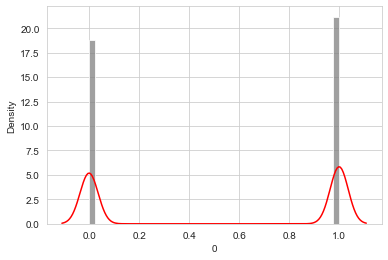

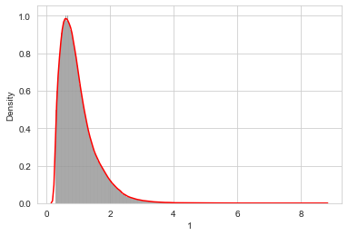

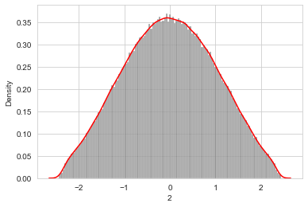

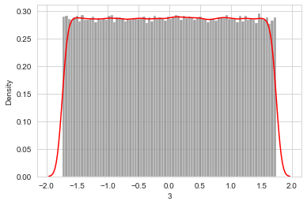

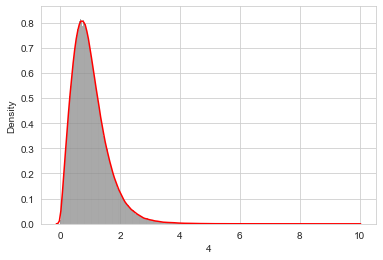

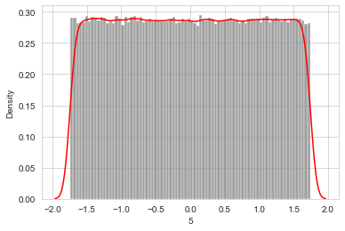

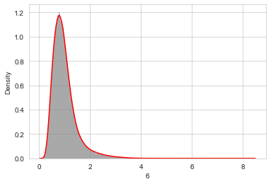

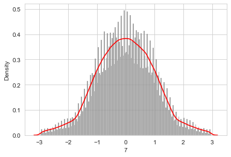

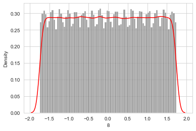

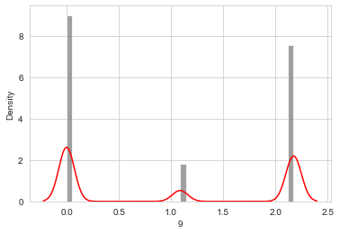

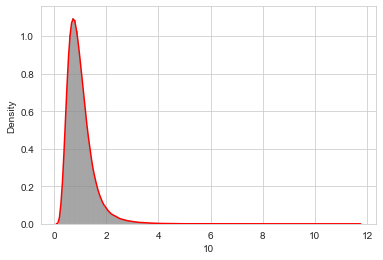

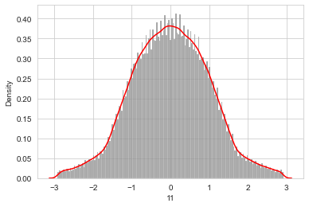

[17 more figures not shown]

```python
for i in data.columns:
    # use distplot function to visualize
    # data column by column.
    # We can observe their distribution and
    # we can also gather information about
    # skewness and kurtosis.
    distplot(viz_data, i, bins="fd")
```

Some features, like 13,17,21 seems categorical. We may want to use one-hot encoding to them but also we can just not doing any modifications.

Also in feature 0, our target, we can see their counts are very close to each other. So this classification will not be focused on imbalanced data.

### Another way to looking distribution

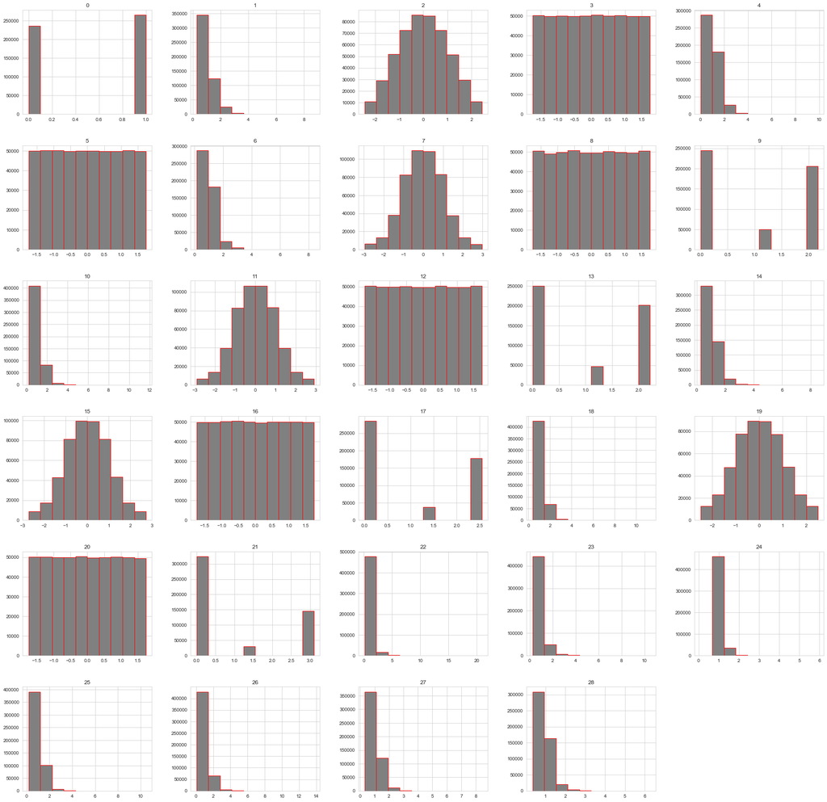

```python
# We can use histograms all of them in same
# plot. It may help, because we're going to
# look all columns in one big plot.
viz_data.hist(figsize=(30, 30), edgecolor="red", color="gray")
plt.show()
```

### Linear Correlation Control

Multicollinearity check is an important step in data preprocessing. It can lead us to better results when we get rid of multicollinearity.

Now we're going to look which features has correlation greater than 0.7 with any feature.

```python
corr_data = viz_data.corr()
high_correlated_features = []
for col in data.columns:
    if len(np.where(abs(corr_data[col]) > 0.7)[0]) > 1:
        high_correlated_features.append(col)
```

```python
corr_data[high_correlated_features].T[[22, 23, 27, 28]]
```

|  | 22 | 23 | 27 | 28 |
| --- | --- | --- | --- | --- |
| 22 | 1.000000 | 0.794191 | 0.455653 | 0.461055 |
| 23 | 0.794191 | 1.000000 | 0.610415 | 0.587433 |
| 27 | 0.455653 | 0.610415 | 1.000000 | 0.894827 |
| 28 | 0.461055 | 0.587433 | 0.894827 | 1.000000 |

If we look particular columns, we can see there is a high correlation between 22-23 and 27-28. We need to remove one of those columns.

22 has high correlation with only 23.

27 has high correlation with 28 but also got some medium level correlation with 23.

28 has high correlation with 27 and it's correlation with 23 is also medium.

So I have decided to remove 22, 27 and 28. 23 is enough for all 3 of them.

Until classification I will let these features stay, so we can inspect them in other plots or statistics.

### Correlation Analysis with Heatmap

We can also check correlations with Heatmap. It can help us to observe which columns have better correlation with column 0, our target column.

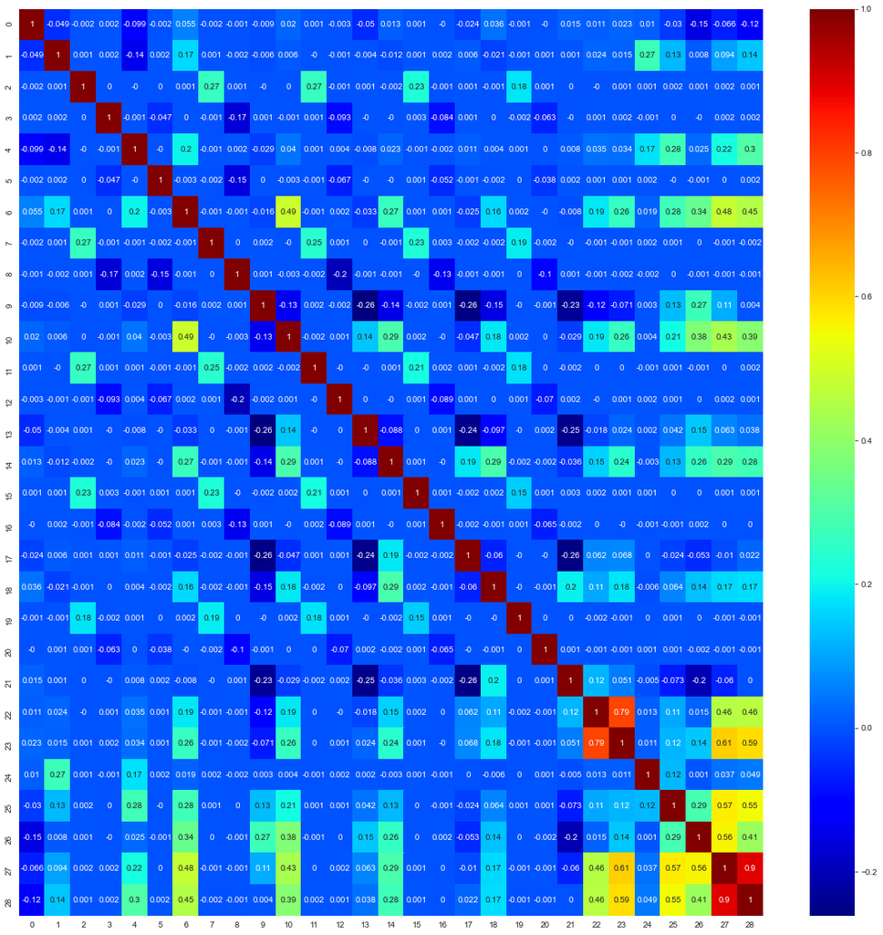

```python
fig, ax = plt.subplots(figsize=(20, 20))
sns.heatmap(np.round(corr_data, 3), annot=True, ax=ax, cmap="jet")
plt.show()
```

Again, high correlations between 22-23 and 27-28. But most of the features are not really linearly correlated with each other. They might have some non-linear correlations or it could be meaningless to each other in anyway.

### Skewness, Kurtosis and Z-Score Analysis

Statistical analysis can provide us better understanding. We may remove or correct some data.

Noone wants a data that has high skewness and kurtosis so we need to find them, if there is we need to fix them also.

```python
def statistical_analysis(data, column, zscore_threshold=3):
    # calculate skewness
    skewness = skew(data[column])
    # calculate kurtosis
    kurt = kurtosis(data[column])
    # calculate Outlier count with Z-Score
    outlier_count = np.sum(zscore(data[column]) > zscore_threshold)
    # Print them out.
    print("Feature Number: {0}".format(column))
    print("Skewness: {0}".format(skewness))
    print("Kurtosis: {0}".format(kurt))
    print("Outlier count with {0} z-score threshold: {1}".format(zscore_threshold, outlier_count))
    print("="*40)
```

```python
# Checkout for statistical analysis
for i in data.columns:
    statistical_analysis(data, i, zscore_threshold=3)
```

```
Feature Number: 0
Skewness: -0.11910732180192737
Kurtosis: -1.985813445893169
Outlier count with 3 z-score threshold: 0
========================================
Feature Number: 1
Skewness: 1.7504305330790912
Kurtosis: 5.465714936330475
Outlier count with 3 z-score threshold: 88418
========================================
Feature Number: 2
Skewness: -2.361554829773598e-05
Kurtosis: -0.6336237718345128
Outlier count with 3 z-score threshold: 0
========================================
Feature Number: 3
Skewness: -0.0006119794545411689
Kurtosis: -1.199426326751665
Outlier count with 3 z-score threshold: 0
========================================
Feature Number: 4
Skewness: 1.4910103048173506
Kurtosis: 4.834910192874453
Outlier count with 3 z-score threshold: 78508
========================================
Feature Number: 5
Skewness: -0.000999612379605523
Kurtosis: -1.1994253854630645
Outlier count with 3 z-score threshold: 0
========================================
Feature Number: 6
Skewness: 1.9062694418713761
Kurtosis: 6.276034721651014
Outlier count with 3 z-score threshold: 119102
========================================
Feature Number: 7
Skewness: 0.0003074864471724914
Kurtosis: -0.014289238730429421
Outlier count with 3 z-score threshold: 0
========================================
```

[output cut: 90 more lines]

```
Feature Number: 26
Skewness: 2.433942510487836
Kurtosis: 13.598153828046193
Outlier count with 3 z-score threshold: 98428
========================================
Feature Number: 27
Skewness: 2.6905955072560546
Kurtosis: 14.533670476626693
Outlier count with 3 z-score threshold: 110890
========================================
Feature Number: 28
Skewness: 2.5477066446550825
Kurtosis: 12.02575515113398
Outlier count with 3 z-score threshold: 112220
========================================
```

We might want to remove those outliers because we have 6 million data and its huge.

### Splitting Data

We are going to split dataset into 3 set. These are train, validation and test set.

#### Explanation of Splitting Data

- Train Set: We're going to use this set in model selection. We will use this data and we will decide which models are good enough to tune.
- Validation Set: With the validation set we will tune our model. With hyper-parameter tuning, our model becomes more robust. If we won't overfit the validation set we can trust our model performance. And if the validation set not very different from the test set we can expect nearly the same scores in the test set.
- Test Set: Finally! We're in final model development phase. We will use Train set to fit our data. And we're going to use hyper-parameters from validation phase. Then we're going to predict test set. We need to get similar scores that we achived in validation set. If we get little bad or little good it might happened because of data distribution and its OK. But if it's very bad then we overfitted to validation set.

```python
trainval, test = train_test_split(data, stratify=data[0], test_size=0.2)
train, val = train_test_split(trainval, stratify=trainval[0], test_size=0.15)
```

```python
print("The data are going to used in training: {0}".format(train.shape[0]))
print("The data are going to used in validation: {0}".format(val.shape[0]))
print("The data are going to used in test: {0}".format(test.shape[0]))
```

```
The data are going to used in training: 4080000
The data are going to used in validation: 720000
The data are going to used in test: 1200000
```

```python
def model_selection(X, y, classifier, scoring=None, cv=None, fold=3):
    # For sake of covering real data.
    Xt = X.copy()
    yt = y.copy()
    # Creating CV method.
    if cv is None:
        cv = StratifiedKFold(n_splits=fold)
    # We are creating evaluation metrics for selecting models.
    if scoring is None:
        scoring = {'roc': 'roc_auc',
                   'log_loss': 'neg_log_loss',
                   'acc': 'accuracy',
                   'f1': 'f1'
                  }
    # Apply cross validation and gather train - test results.
    cv_result = cross_validate(estimator=classifier, X=Xt, y=yt, cv=cv, n_jobs=-1,
                               return_train_score=True, scoring=scoring)
    # Use scoring keys for accessing scores/errors.
    # Train results
    train_roc_mean = np.mean(cv_result['train_roc'])
    train_log_loss_mean = abs(np.mean(cv_result['train_log_loss']))
    train_acc_mean = np.mean(cv_result['train_acc'])
    train_f1_mean = np.mean(cv_result['train_f1'])
    # Test results
    test_roc_mean = np.mean(cv_result['test_roc'])
    test_log_loss_mean = abs(np.mean(cv_result['test_log_loss']))
    test_acc_mean = np.mean(cv_result['test_acc'])
    test_f1_mean = np.mean(cv_result['test_f1'])

    return (train_roc_mean, test_roc_mean), (train_log_loss_mean, test_log_loss_mean), \
           (train_acc_mean, test_acc_mean), (train_f1_mean, test_f1_mean)
```

```python
def multi_model_selection(X, y, classfier_list, scoring=None, cv=None, fold=3):
    # Metrics are in the same order that 'model_selection' function returns.
    metrics = ['roc', 'log_loss', 'acc', 'f1']
    # Create empty dataframe for results
    result_df = pd.DataFrame(columns=['Model_Name', 'Train_Result', 'Test_Result', 'Metric_Name'])
    # Run 'model_selection' function for every model
    for model in classfier_list:
        model_name = type(model).__name__
        model_result = model_selection(X, y, model)
        # We're transfering the results to Dataframe
        for result, metric in zip(model_result, metrics):
            result_df = result_df.append({'Model_Name': model_name,'Train_Result': result[0],
                                          'Test_Result': result[1],'Metric_Name': metric},
                                         ignore_index=True)
    return result_df
```

We have 6 million samples and its too much to observing. I'm going to use 100.000 data in model selection because even 300.000 samples takes too long.

```python
X_train = train[0:100_000].drop([0], axis=1)
y_train = train[0:100_000][0]
```

```python
models = [
    LogisticRegression(),
    GaussianNB(),
    AdaBoostClassifier(),
    DecisionTreeClassifier(),
    ExtraTreesClassifier(),
    XGBClassifier(),
    LGBMClassifier(),
    RandomForestClassifier(),
    MLPClassifier()]
results = multi_model_selection(X_train, y_train, models)
results[["Train_Result", "Test_Result"]] = np.round(results[["Train_Result", "Test_Result"]], 4)
```

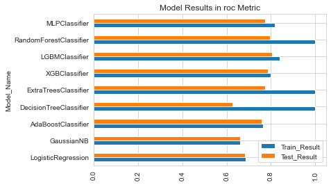

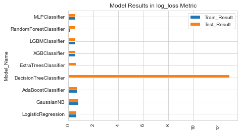

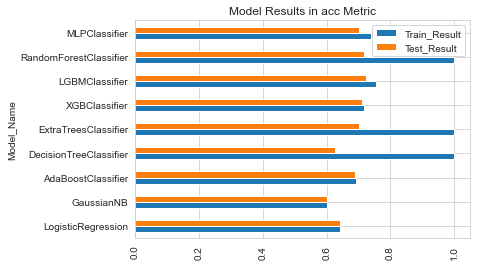

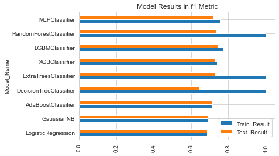

```python
for metric in results["Metric_Name"].unique().tolist():
    fig, ax = plt.subplots()
    plt.title('Model Results in {0} Metric'.format(metric))
    plt.xticks(rotation=90)
    results[results['Metric_Name'] == metric].plot(kind='barh', x='Model_Name', ax=ax)
    plt.show()
```

As we can see some models already overfitted to data. These models are Random Forest, Extra Tree and Decision Tree models. So, I decided to picking best models that they are not overfitted or underfitted yet.

If i need to be more specific on that, I will take XGB, LGBM, MLP and Adaboost to inspect them. Then I will pick some of them to tuning.

```python
good_models = results[(results["Model_Name"] == "MLPClassifier") |
                      (results["Model_Name"] == "XGBClassifier") |
                      (results["Model_Name"] == "LGBMClassifier") |
                      (results["Model_Name"] == "AdaBoostClassifier")].reset_index(drop=True)
```

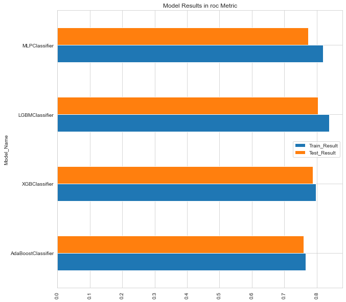

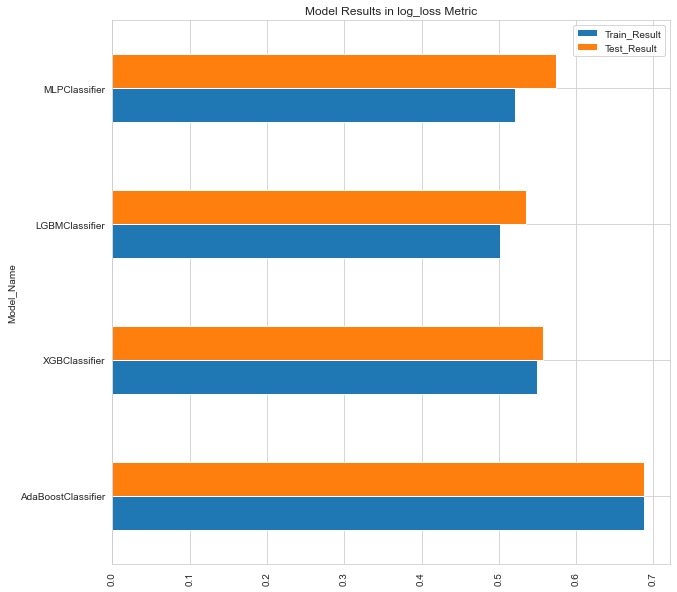

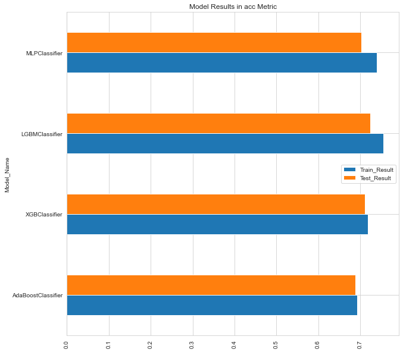

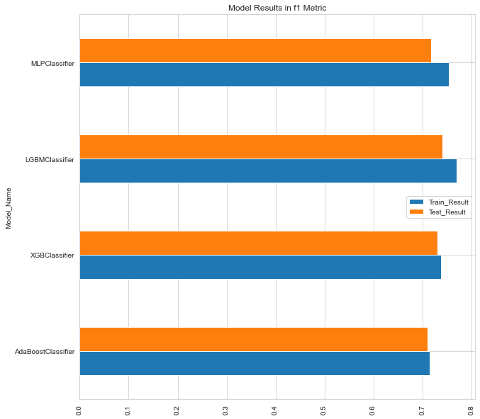

```python
for metric in good_models["Metric_Name"].unique().tolist():
    fig, ax = plt.subplots(figsize=(10, 10))
    plt.title('Model Results in {0} Metric'.format(metric))
    plt.xticks(rotation=90)
    good_models[good_models['Metric_Name'] == metric].plot(kind='barh', x='Model_Name', ax=ax)
    plt.show()
```

### Tuning model

We're going to tune XGB and LGBM model. Because in model selection their scores better than others. With tuning model we will decide our final model for final model development phase.

After working with XGB I decided to not tune XGB because it takes too much time to fit data.

When tuning comes in we can think about grid search CV but we have so huge data. So actually we can split data and evaluate through validation data.

There is an another option too. We can combine our training and validation data then we can use Grid Search CV to optimize model parameters then selecting best parameters.

Because of huge data, using Grid Search CV with training and validation data will take good deal of time. So I will use splitted data.

```python
def calc_metrics(y_true, y_pred, y_proba, verbose=True):
    roc = roc_auc_score(y_true, y_pred)
    loss = log_loss(y_true, y_proba)
    acc = accuracy_score(y_true, y_pred)
    f1 = f1_score(y_true, y_pred)

    if verbose:
        print("ROC Score: {0}".format(roc))
        print("Log Loss: {0}".format(loss))
        print("Accuracy: {0}".format(acc))
        print("F1 Score: {0}".format(f1))

    return roc, loss, acc, f1
```

```python
def model_tuning(X_train, y_train, X_val, y_val, classifier, param_grid):
    # Store metrics for plotting
    # Roc Scores
    train_roc_scores = []
    val_roc_scores = []
    # Accuracy Scores
    train_acc_scores = []
    val_acc_scores = []
    # Log Loss Scores
    train_log_loss_scores = []
    val_log_loss_scores = []
    # F1 Scores
    train_f1_scores = []
    val_f1_scores = []

    grids = list(ParameterGrid(param_grid))

    for grid in grids:
        classifier.set_params(**grid)
        classifier.fit(X_train, y_train)
        # Train Prediction
        y_train_predict = classifier.predict(X_train)
        y_train_proba = classifier.predict_proba(X_train)
        # Validation Prediction
        y_val_predict = classifier.predict(X_val)
        y_val_proba = classifier.predict_proba(X_val)
        # Get metrics
        train_roc, train_loss, train_acc, train_f1 = calc_metrics(y_train, y_train_predict, y_train_proba, verbose=False)
        val_roc, val_loss, val_acc, val_f1 = calc_metrics(y_val, y_val_predict, y_val_proba, verbose=False)

        # Store metrics for plotting
        train_roc_scores.append(train_roc)
        val_roc_scores.append(val_roc)

        train_acc_scores.append(train_acc)
        val_acc_scores.append(val_acc)

        train_log_loss_scores.append(train_loss)
        val_log_loss_scores.append(val_loss)

        train_f1_scores.append(train_f1)
        val_f1_scores.append(val_f1)

    # For title in metrics
    metrics = ["ROC", "Accuracy",  "F1", "Log Loss"]
    # Storing
    train_results = [train_roc_scores, train_acc_scores, train_f1_scores, train_log_loss_scores]
    val_results = [val_roc_scores, val_acc_scores, val_f1_scores, val_log_loss_scores]
    # plotting result of train-validation results.
    # it will help us to determine which grid
    # is better or which grid overfitted
    plot_result.plot_validation(grids, train_results, val_results, metrics=metrics)
```

```python
X_train = train.drop([0], axis=1)
y_train = train[0]
```

```python
X_val = val.drop([0], axis=1)
y_val = val[0]
```

```python
clf = LGBMClassifier(n_jobs=-1)
param_grid = {'learning_rate': [0.05, 0.1, 0.2],
              'n_estimators': [75, 100, 150]}
```

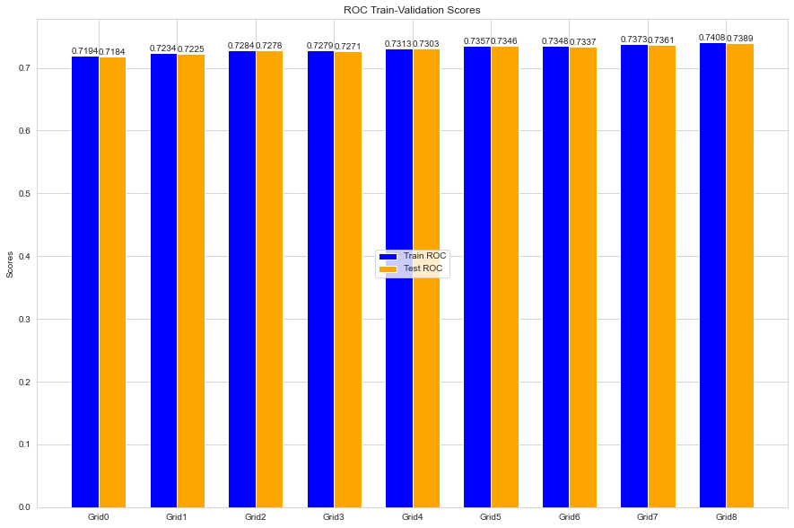

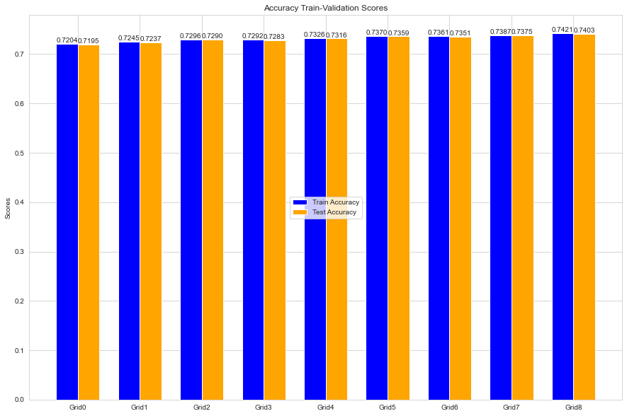

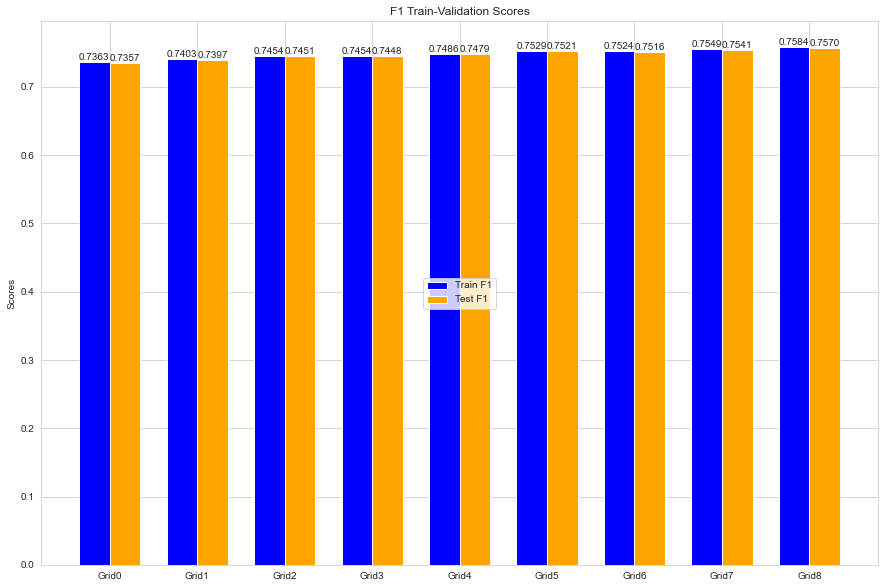

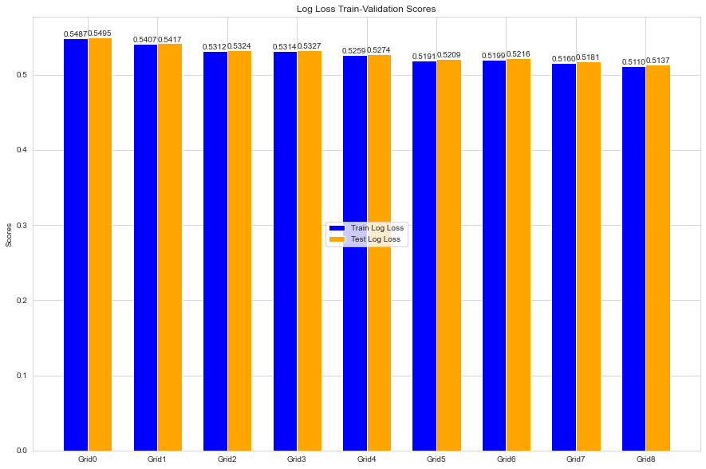

```
Grid0: {'learning_rate': 0.05, 'n_estimators': 75}
Grid1: {'learning_rate': 0.05, 'n_estimators': 100}
Grid2: {'learning_rate': 0.05, 'n_estimators': 150}
Grid3: {'learning_rate': 0.1, 'n_estimators': 75}
Grid4: {'learning_rate': 0.1, 'n_estimators': 100}
Grid5: {'learning_rate': 0.1, 'n_estimators': 150}
Grid6: {'learning_rate': 0.2, 'n_estimators': 75}
Grid7: {'learning_rate': 0.2, 'n_estimators': 100}
Grid8: {'learning_rate': 0.2, 'n_estimators': 150}
```

```python
tuning_result = model_tuning(X_train, y_train, X_val, y_val, clf, param_grid)
```